```python
import pandas as pd
import matplotlib.pyplot as plt
import numpy as np
from sklearn.linear_model import LinearRegression
import seaborn as sns
import statsmodels.api as sm
from sklearn.metrics import r2_score, mean_squared_error
from IPython.display import Image
```

# Crime and Unemployment - Practical

## Problem 1

1. Firstly let’s look at our data. This is the most important part of econometrics, and it is often forgotten. Let’s draw a histogram of the Violence data. Left click on the ’Violence’ data to select it, then Variable → Frequency distribution, at the top of the Gretl GUI. Select the number of bins equal to 19, and select the then click ’ok’. A nice histogram should pop up as a figure.

```python
violence_data = pd.read_excel("problemset1.xls", index_col=0)
violence_data
```

| State | Unemployment | Violence |
| --- | --- | --- |
| Alabama | 7.2 | 383.7 |
| Alaska | 7.0 | 635.3 |
| Arizona | 7.7 | 413.6 |
| Arkansas | 7.2 | 503.5 |
| California | 8.9 | 439.6 |
| Colorado | 6.9 | 323.7 |
| Connecticut | 7.8 | 282.0 |
| Delaware | 6.7 | 623.3 |
| District of Columbia | 8.5 | 1326.8 |
| Florida | 7.2 | 541.3 |
| Georgia | 8.2 | 402.3 |
| Hawaii | 4.9 | 264.3 |
| Idaho | 6.1 | 220.5 |
| Illinois | 9.0 | 444.9 |
| Indiana | 7.7 | 323.3 |
| Iowa | 4.7 | 268.5 |
| Kansas | 5.3 | 370.8 |
| Kentucky | 8.0 | 243.9 |
| Louisiana | 6.7 | 555.3 |
| Maine | 6.6 | 122.1 |
| Maryland | 6.6 | 546.3 |
| Massachusetts | 6.7 | 468.9 |
| Michigan | 8.8 | 493.0 |
| Minnesota | 5.0 | 235.7 |
| Mississippi | 8.5 | 269.3 |
| Missouri | 6.7 | 457.7 |
| Montana | 5.4 | 275.8 |
| Nebraska | 3.8 | 278.3 |
| Nevada | 9.6 | 663.0 |
| New Hampshire | 5.1 | 167.4 |
| New Jersey | 8.2 | 307.5 |
| New Mexico | 6.9 | 588.0 |
| New York | 7.7 | 394.4 |
| North Carolina | 8.0 | 362.7 |
| North Dakota | 2.9 | 229.5 |
| Ohio | 7.5 | 314.7 |
| Oklahoma | 5.3 | 481.4 |
| Oregon | 7.9 | 251.4 |
| Pennsylvania | 7.4 | 366.5 |
| Rhode Island | 9.3 | 257.4 |
| South Carolina | 7.6 | 602.2 |
| South Dakota | 3.8 | 268.9 |
| Tennessee | 7.8 | 612.0 |
| Texas | 6.3 | 448.4 |
| Utah | 4.6 | 213.5 |
| Vermont | 4.4 | 131.0 |
| Virginia | 5.7 | 214.2 |
| Washington | 7.0 | 313.5 |
| West Virginia | 6.8 | 301.2 |
| Wisconsin | 6.7 | 248.9 |
| Wyoming | 4.7 | 197.9 |

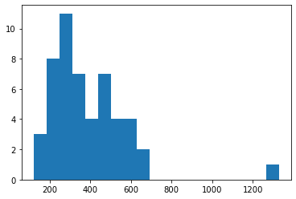

```python
plt.hist(x=violence_data["Violence"], bins=19)
```

## Problem 2

1. Draw a similar histogram (with 19 bins) of the Unemployment data, and report the unemployment rate bin which has the highest frequency.

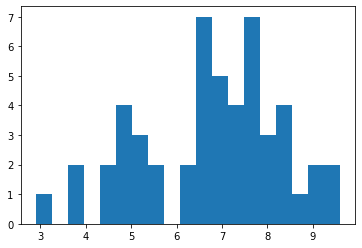

```python
plt.hist(x=violence_data["Unemployment"],bins=19)
```

Approximating the intervals for the bins, the bins that share the highest frequency are the bins on the interval (6.5,6.9) and (7.75,8).

## Problem 3

1. Can you find out which State has the highest rate of violent crime reported? To do this you just need to click on the ’Violence’ variable, then look for the state with the highest violence rate.

```python
violence_data["Violence"].idxmax(axis=0)
```

```
'District of Columbia'
```

The State with the highest rate of violent crime reported is District of Columbia (if D.C. counts).

```python
violence_data.sort_values(by="Violence",ascending=False).index[1]
```

```
'Nevada'
```

If D.C. doesn’t count, then Nevada is the answer.

## Problem 4

1. Another way of understanding a dataset it to look at its summary statistics. Gretl provides a nice, and simple way of doing this. In order to view this information for a given variable, just click ’Variable’ → ’Summary Statistics’. This will provide a statistical summary of a given variable. Why not have a look at the Unemployment dataset’s summary statistics?

```python
violence_data.describe()
```

|  | Unemployment | Violence |
| --- | --- | --- |
| count | 51.000000 | 51.000000 |
| mean | 6.764706 | 385.280392 |
| std | 1.539328 | 195.113742 |
| min | 2.900000 | 122.100000 |
| 25% | 5.550000 | 260.850000 |
| 50% | 6.900000 | 323.700000 |
| 75% | 7.800000 | 475.150000 |
| max | 9.600000 | 1326.800000 |

## Problem 5

1. Let’s look at whether it we can visibly see if there is any relationship between unemployment and violent crime rates by drawing a scatterplot. To do this go to View → Graph specified vars → X-Y scatter. Then select ’Violence’ as a Yaxis variable variable, and ’Unemployment’ as an X-axis variable. This should produce a scatterplot with a fitted regression line. From this, there appears to be some sort of positive relationship between ’Violence’ and ’Unemployment’.

```python
x1 = sm.add_constant(violence_data["Unemployment"])
y1 = violence_data["Violence"]
```

```python
lm1 = sm.OLS(y1, x1).fit()
print(lm1.params)
```

```
const           24.397893
Unemployment    53.347848
dtype: float64
```

```python
Pred_Violence = lm1.predict(x1)
violence_data = violence_data.merge(Pred_Violence.rename('Pred_Violence'), left_index=True, right_index=True)
violence_data
```

| State | Unemployment | Violence | Pred_Violence |
| --- | --- | --- | --- |
| Alabama | 7.2 | 383.7 | 408.502396 |
| Alaska | 7.0 | 635.3 | 397.832827 |
| Arizona | 7.7 | 413.6 | 435.176320 |
| Arkansas | 7.2 | 503.5 | 408.502396 |
| California | 8.9 | 439.6 | 499.193737 |
| Colorado | 6.9 | 323.7 | 392.498042 |
| Connecticut | 7.8 | 282.0 | 440.511105 |
| Delaware | 6.7 | 623.3 | 381.828473 |
| District of Columbia | 8.5 | 1326.8 | 477.854598 |
| Florida | 7.2 | 541.3 | 408.502396 |
| Georgia | 8.2 | 402.3 | 461.850244 |
| Hawaii | 4.9 | 264.3 | 285.802347 |
| Idaho | 6.1 | 220.5 | 349.819764 |
| Illinois | 9.0 | 444.9 | 504.528522 |
| Indiana | 7.7 | 323.3 | 435.176320 |
| Iowa | 4.7 | 268.5 | 275.132777 |
| Kansas | 5.3 | 370.8 | 307.141486 |
| Kentucky | 8.0 | 243.9 | 451.180675 |
| Louisiana | 6.7 | 555.3 | 381.828473 |
| Maine | 6.6 | 122.1 | 376.493688 |
| Maryland | 6.6 | 546.3 | 376.493688 |
| Massachusetts | 6.7 | 468.9 | 381.828473 |
| Michigan | 8.8 | 493.0 | 493.858953 |
| Minnesota | 5.0 | 235.7 | 291.137132 |
| Mississippi | 8.5 | 269.3 | 477.854598 |
| Missouri | 6.7 | 457.7 | 381.828473 |
| Montana | 5.4 | 275.8 | 312.476271 |
| Nebraska | 3.8 | 278.3 | 227.119714 |
| Nevada | 9.6 | 663.0 | 536.537231 |
| New Hampshire | 5.1 | 167.4 | 296.471916 |
| New Jersey | 8.2 | 307.5 | 461.850244 |
| New Mexico | 6.9 | 588.0 | 392.498042 |
| New York | 7.7 | 394.4 | 435.176320 |
| North Carolina | 8.0 | 362.7 | 451.180675 |
| North Dakota | 2.9 | 229.5 | 179.106651 |
| Ohio | 7.5 | 314.7 | 424.506751 |
| Oklahoma | 5.3 | 481.4 | 307.141486 |
| Oregon | 7.9 | 251.4 | 445.845890 |
| Pennsylvania | 7.4 | 366.5 | 419.171966 |
| Rhode Island | 9.3 | 257.4 | 520.532877 |
| South Carolina | 7.6 | 602.2 | 429.841536 |
| South Dakota | 3.8 | 268.9 | 227.119714 |
| Tennessee | 7.8 | 612.0 | 440.511105 |
| Texas | 6.3 | 448.4 | 360.489334 |
| Utah | 4.6 | 213.5 | 269.797992 |
| Vermont | 4.4 | 131.0 | 259.128423 |
| Virginia | 5.7 | 214.2 | 328.480625 |
| Washington | 7.0 | 313.5 | 397.832827 |
| West Virginia | 6.8 | 301.2 | 387.163257 |
| Wisconsin | 6.7 | 248.9 | 381.828473 |
| Wyoming | 4.7 | 197.9 | 275.132777 |

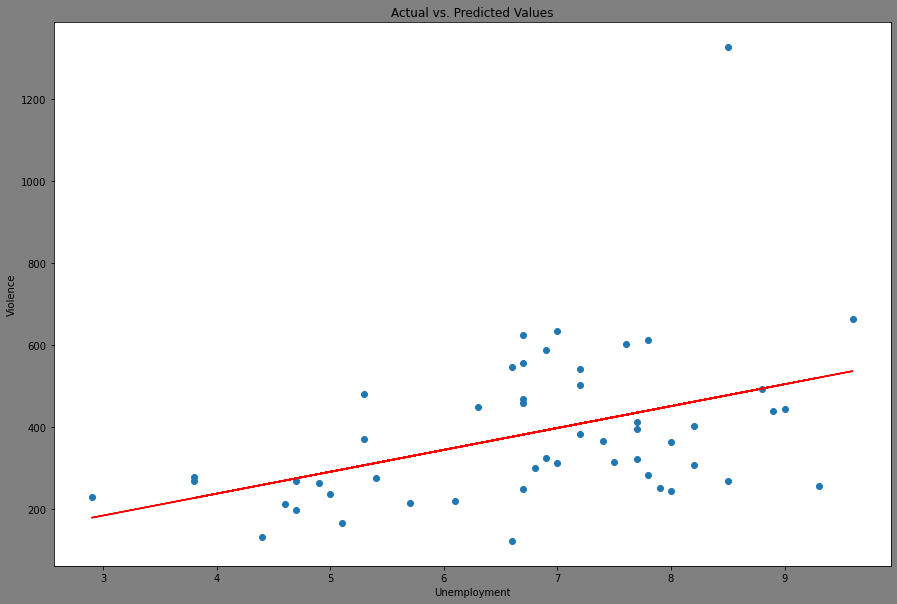

```python
plt.figure(figsize=(15,10), facecolor="grey")
plt.title("Actual vs. Predicted Values")
plt.xlabel("Unemployment")
plt.ylabel("Violence")
plt.scatter("Unemployment","Violence",data=violence_data)
plt.plot("Unemployment", "Pred_Violence", data=violence_data, color="red")
```

## Problem 6

1. One way of quantifying the relationship between two variables is via their correlation coefficient. You can find this on Gretl by going to ’View’ → ’Correlation matrix. If you then select both ’Violence’ and ’Unemployment’ you should see an outputted correlation (along with associated p values etc.) of around 0.42. What does this mean?

```python
np.corrcoef(x=violence_data["Violence"], y=violence_data["Unemployment"])[0,1]
```

```
0.4208817510627497
```

The correlation between ‘Violence’ and ‘Unemployment’ is 0.4208818. This value means there’s a positive correlation between ‘Violence’ and ‘Unemployment.’ More specifically, when the value for ‘Violence’ exceeds its average, ‘Unemployment’ also tends to exceed its respective average.

## Problem 7

1. Since we’ve inspected our variables sufficiently, it is now time to run our first regression. Let’s run an ordinary least squares regression with ’Violence’ as a dependent variable, and ’Unemployment’ (and a constant) as an independent variable. To do this go to ’Model’ → ’Ordinary Least Squares’. Then select ’Violence’ as a dependent variable, and ’Unemployment’ as an independent (a constant should already be in the list of independent variables) and click ’ok’. This should provide a read-out of the results from your first OLS regression!

```python
lm1.summary2()
```

| Model: | OLS | Adj. R-squared: | 0.160 |
| --- | --- | --- | --- |
| Dependent Variable: | Violence | AIC: | 675.6837 |
| Date: | 2022-02-13 20:02 | BIC: | 679.5474 |
| No. Observations: | 51 | Log-Likelihood: | -335.84 |
| Df Model: | 1 | F-statistic: | 10.55 |
| Df Residuals: | 49 | Prob (F-statistic): | 0.00210 |
| R-squared: | 0.177 | Scale: | 31965. |

|  | Coef. | Std.Err. | t | P>\|t\| | [0.025 | 0.975] |
| --- | --- | --- | --- | --- | --- | --- |
| const | 24.3979 | 113.8998 | 0.2142 | 0.8313 | -204.4924 | 253.2882 |
| Unemployment | 53.3478 | 16.4256 | 3.2478 | 0.0021 | 20.3394 | 86.3563 |

| Omnibus: | 43.512 | Durbin-Watson: | 1.827 |
| --- | --- | --- | --- |
| Prob(Omnibus): | 0.000 | Jarque-Bera (JB): | 191.095 |
| Skew: | 2.169 | Prob(JB): | 0.000 |
| Kurtosis: | 11.433 | Condition No.: | 32 |

## Problem 8

1. What is the coefficient on ’Unemployment’? What is the interpretation of this value?

```python
lm1.params[1]
```

```
53.34784767389902
```

The coefficient of ‘Unemployment’ is 53.34784767389902. This means for every percentage (unit) increase in ‘Unemployment,’ one can expect a 53.34784767389902 unit increase in ‘Violence.’

## Problem 9

1. What would this model predict would be the increase in the rate of violent crime for a 1 standard deviation increase in unemployment? What is this increase in terms of standard deviations of the rate of violence?

```python
np.std(violence_data[["Unemployment"]],ddof=1)[0] * lm1.params[1]
```

```
82.11981348708322
```

```python
np.std(violence_data[["Unemployment"]],ddof=1)[0] * lm1.params[1] / np.std(violence_data[["Violence"]])[0]
```

```
0.42506973233247186
```

This model would predict an increase of 82.11981348708322 cases for a 1 standard deviation (1.5393275842927996 units) increase in unemployment. In terms of standard deviations of the rate of violence, this is a 0.42506973233247186 standard deviation increase in the rate of violence.

## Problem 10

1. What does a regression of the rate of unemployment on violent crime rates (the other way round to that in the last part) suggest would be the increase in the unemployment rate for a 1 standard deviation increase in the rate of violent crime?

```python
x2 = sm.add_constant(violence_data["Violence"])
y2 = violence_data["Unemployment"]
```

```python
lm2 = sm.OLS(y2, x2).fit()
```

```python
lm2.params[1] * np.std(violence_data[["Violence"]],ddof=1)[0]
```

```
0.6478748891363445
```

## Problem 11

1. Can you use this regression to uncover what it suggests the increase in unemployment associated with a 1 standard deviation increase in violent crime? Is this the same as we found previously? Why is this the same/different?

## Problem 12

1. What can you conclude about the causal mechanism between violent crime and unemployment based on the two regressions you have run? Does violent crime cause unemployment or vice versa?

No, the regression certainly doesn’t entail any causality. It’s likely there are several other unmeasurable factors that are influencing the violence rate and are also correlated with unemployment.

## Problem 13

1. Why might it be incorrect to conclude that increases in unemployment lead to increases in rates of violent crime?

This notion implies causality when the data provided doesn’t allow us to draw causal inferences. An experiment where all other factors are held constant while allowing unemployment and violence to vary would allow us to draw such a conclusion.

# Theory

## Problem 1

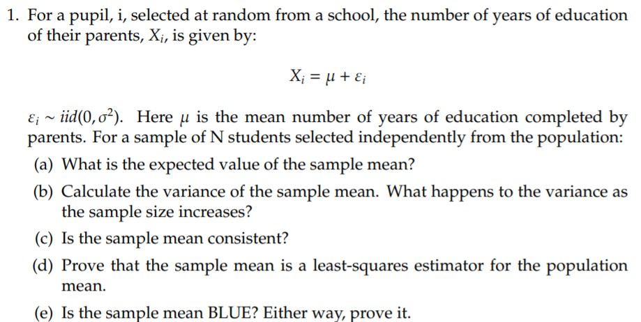

```python
Image("Screenshot_Problem_1.jpg")
```

1. a. $$E[\bar{X}]=E[\frac{1}{N}\sum_{i=1}^{N}X_i]$$ $$=\frac{1}{N}E[\sum_{i=1}^{N}X_i]$$ $$=\frac{1}{N}\sum_{i=1}^{N}E[X_i]$$ $$=\frac{1}{N}\sum_{i=1}^{N}E[\mu + \epsilon_i]$$ $$=\frac{1}{N}\sum_{i=1}^{N}(E[\mu] + E[\epsilon_i])$$ $$=\frac{1}{N}\sum_{i=1}^{N}(E[\mu] + 0)$$ $$=\frac{1}{N}\sum_{i=1}^{N}\mu$$ $$=\frac{1}{N}\cdot N\cdot\mu = \mu$$

b. $$Var(\bar{X})=Var(\frac{1}{N}\sum_{i=1}^{N}X_i)$$ $$=\frac{1}{N^2}Var(\sum_{i=1}^{N}X_i)$$ $$=\frac{1}{N^2}\cdot N\cdot Var(X)=\frac{\sigma_X^2}{N}$$ Note: The sum of variances only works here (without the covariance terms) because of the independence of the X's.\

c. Since $\bar{X}$ was proven unbiased as an estimator of the population mean, to prove consistency for $\bar{X}$, it suffices to show the variance of $\bar{X}$ tends to zero as $N\to\infty$. In this case, $\lim_{N\to\infty}Var(\bar{X})=\lim_{N\to\infty}\frac{\sigma_X^2}{N}=0$.

d. For the population mean, there exists an estimator, which we will denote as $\hat{\mu}$, that solves $\min S= \sum_{i=1}^{N}(X_i-\hat{\mu})^2$. $$\frac{\partial S}{\partial\hat{\mu}}=\sum_{i=1}^{N}-2(X_i-\hat{\mu})=0$$ $$\to \sum_{i=1}^{N}(X_i-\hat{\mu})=0$$ $$\to \sum_{i=1}^{N}X_i= \sum_{i=1}^{N}\hat{\mu}$$ $$\to N\cdot\bar{X}= N\cdot\hat{\mu}$$ $$\to \hat{\mu}=\bar{X}$$

e. Yes, the sample mean $\bar{X}$ is the best linear unbiased estimator (BLUE) of the population mean. In part(a), we proved $E[\bar{X}]=\mu$, and thus the sample mean is an unbiased estimator. Thus, we must show $\bar{X}$ is the variance minimizing estimator for $\mu$. To prove this, take an estimator of $\mu, \hat{\mu}=\sum_{i=1}^N(\omega_i\cdot X_i)$, where $\sum_{i=1}^{N}\omega_i=1$. The problem then becomes:

$$\min Var(\hat{\mu}) \: s.t. \: \omega_1+...+\omega_N=1$$$$\to \min Var(\sum_{i=1}^N(\omega_i\cdot X_i)) \: s.t. \: \omega_1+...+\omega_N=1$$$$\to \min Var(\omega_1\cdot X_1 + ... + \omega_N\cdot X_N) \: s.t. \: \omega_1+...+\omega_N=1$$$$\to \min Var(\omega_1\cdot X_1) + ... + Var(\omega_N\cdot X_N) \: s.t. \: \omega_1+...+\omega_N=1$$$$\to \min \omega_1^2Var(X_1) + ... + \omega_N^2Var(X_N) \: s.t. \: \omega_1+...+\omega_N=1$$$$\to \min \omega_1^2\sigma_X^2 + ... + \omega_N^2\sigma_X^2 \: s.t. \: \omega_1+...+\omega_N=1$$$$\to \mathscr{L} = \omega_1^2\sigma_X^2 + ... + \omega_N^2\sigma_X^2 - \lambda(\omega_1+...+\omega_N-1)$$$$\frac{\partial\mathscr{L}}{\partial\omega_1}=2\sigma_X^2\omega_1-\lambda=0$$$$...$$$$\frac{\partial\mathscr{L}}{\partial\omega_N}=2\sigma_X^2\omega_N-\lambda=0$$$$\to 2\sigma_X^2\omega_1 -\lambda = ... =2\sigma_X^2\omega_N -\lambda$$$$\to 2\sigma_X^2\omega_1 = ... =2\sigma_X^2\omega_N$$$$ \to \omega_1 = ... = \omega_N$$$$ \to \omega_1 + ... + \omega_N = 1 = N\cdot\omega_1$$$$ \to \omega_1 = ... = \omega_N = \frac{1}{N}$$$$ \to \hat{\mu} = \frac{1}{N}\sum_{i=1}^{N}X_i=\bar{X}$$

## Problem 2

1. For each of the following state whether or not the estimator is biased, consistent, both or neither, when used to estimate the population mean:

a. $\tilde{X}=\frac{1}{N-1}\sum_{i=1}^{N}X_i$ $$E[\tilde{X}] = E[\frac{1}{N-1}\sum_{i=1}^{N}X_i]=\frac{1}{N-1}\sum_{i=1}^{N}E[X_i]=\frac{1}{N-1}\sum_{i=1}^{N}\mu=\frac{1}{N-1}\cdot N \mu\neq \mu$$ $$\lim_{N\to\infty}Var(\tilde{X})=\lim_{N\to\infty}Var(\frac{1}{N-1}\sum_{i=1}^{N}X_i)=\lim_{N\to\infty} \frac{N}{(N-1)^2}\cdot Var(X) = 0$$ $\therefore \tilde{X}$ displays consistency but not unbiasedness.\

b. $\hat{X}=\frac{2}{N}\sum_{i=1}^{N/2}X_i$ $$E[\hat{X}]=E[\frac{2}{N}\sum_{i=1}^{N/2}X_i] = \frac{2}{N}\sum_{i=1}^{N/2}E[X_i] = \frac{2}{N}\cdot\frac{N}{2}\cdot\mu=\mu$$ $$\lim_{N\to\infty}Var(\hat{X})=\lim_{N\to\infty}Var(\frac{2}{N}\sum_{i=1}^{N/2}X_i) = \lim_{N\to\infty}\frac{4}{N^2}\cdot\frac{N}{2}\cdot \sigma_X^2=\lim_{N\to\infty}\frac{2}{N}\cdot\sigma_X^2=0$$ $\therefore \hat{X}$ displays both consistency and unbiasedness.

d. $Y\: \sim \: N(\mu,\sigma^2)$ $$E[Y]=\mu$$ $$\lim_{N\to\infty}Var(Y)=\sigma^2$$ $\therefore$ Y is unbiased but not consistent.

e. $Z=\sum_{i=1}^{N}w_iX_i$ where $\sum_{i=1}^{N}w_i=1$. $$E[Z]=E[\sum_{i=1}^{N}w_iX_i]=\sum_{i=1}^{N}E[w_iX_i]=\sum_{i=1}^{N}E[w_i]E[X_i]=\mu\sum_{i=1}^{N}E[w_i]=\mu$$ $$\lim_{n\to\infty}Var(Z)=\lim_{n\to\infty}Var(\sum_{i=1}^{N}w_iX_i)=\lim_{n\to\infty}\sum_{i=1}^{N}w_i^2Var(X_i)=0$$ $\therefore Z$ is both consistent and unbiased.

## Problem 3

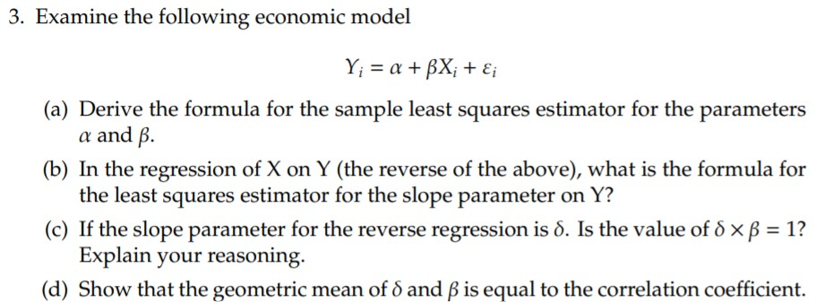

```python
Image("Screenshot_Problem_3.jpg")
```

1. a. $$\min SSR=\sum_{i=1}^{N}(Y_i-\hat{Y}_i)^2=\sum_{i=1}^{N}(Y_i-(\hat{\alpha} + \hat{\beta}X_i))^2$$ $$\frac{\partial SSR}{\partial\alpha}=-2\sum_{i=1}^{N}(Y_i-\hat{\alpha} - \hat{\beta}X_i)=0$$ $$\to \sum_{i=1}^{N}Y_i=\sum_{i=1}^{N}(\hat{\alpha} + \hat{\beta}X_i)$$ $$\to N\bar{Y}=N\hat{\alpha}+N\hat{\beta}\bar{X}$$ $$\to \bar{Y}=\hat{\alpha}+\hat{\beta}\bar{X}$$ $$\to \hat{\alpha} = \bar{Y}-\hat{\beta}\bar{X}$$ $$\frac{\partial SSR}{\partial\beta}=-2\sum_{i=1}^{N}X_i(Y_i-\hat{\alpha} - \hat{\beta}X_i)=0$$ $$\to \sum_{i=1}^{N}X_iY_i=\sum_{i=1}^{N}(\hat{\alpha}X_i+\hat{\beta}X_i^2)$$ $$\to \sum_{i=1}^{N}X_iY_i=\hat{\alpha}N\bar{X}+\hat{\beta}\sum_{i=1}^{N}X_i^2$$ $$\to \sum_{i=1}^{N}X_iY_i=N(\bar{Y}-\hat{\beta}\bar{X})\bar{X}+\hat{\beta}\sum_{i=1}^{N}X_i^2$$ $$\to \sum_{i=1}^{N}X_iY_i -N\bar{X}\bar{Y}=\hat{\beta}(\sum_{i=1}^{N}X_i^2 - N\bar{X}^2)$$ $$\to \hat{\beta}=\frac{\sum_{i=1}^{N}X_iY_i -\bar{X}\sum_{i=1}^{N}Y_i}{\sum_{i=1}^{N}X_i^2 - \bar{X}\sum_{i=1}^{N}X_i}$$ $$\to \hat{\beta}=\frac{\sum_{i=1}^{N}X_iY_i -\bar{X}Y_i}{\sum_{i=1}^{N}X_i^2 - \bar{X}X_i}$$ $$\to \hat{\beta}=\frac{\sum_{i=1}^{N}Y_i(X_i -\bar{X})}{\sum_{i=1}^{N}X_i(X_i - \bar{X})}$$ $$\to \hat{\beta}=\frac{\sum_{i=1}^{N}(Y_i-\bar{Y})(X_i -\bar{X})}{\sum_{i=1}^{N}(X_i - \bar{X})(X_i - \bar{X})}$$ $$\to \hat{\beta}=\frac{\hat{cov}(X,Y)}{\hat{var(X)}}$$

b. Slope parameter on Y = $\hat{\delta}=\frac{\hat{cov}(Y,X)}{\hat{var}(Y)}$

c. No, $\hat{\delta}\times\hat{\beta}=\frac{\hat{cov}(Y,X)}{\hat{var}(Y)}\times\frac{\hat{cov}(X,Y)}{\hat{var(X)}}=\frac{(\sum_{i=1}^{N}(X_i-\bar{X})(Y_i-\bar{Y}))^2}{\sum_{i=1}^{N}(X_i-\bar{X})^2\sum_{i=1}^{N}(Y_i-\bar{Y})^2}\neq 1$

d. $\hat{\delta}\times\hat{\beta}=\frac{\hat{cov}(X,Y)^2}{\hat{var}(X)\hat{var}(Y)}$ $$\hat{\rho}=\frac{\hat{cov}(X,Y)}{\hat{\sigma_X}\hat{\sigma_Y}}$$ $$\to \hat{\rho} = \sqrt{\hat{\delta}\times\hat{\beta}}$$

## Problem 4

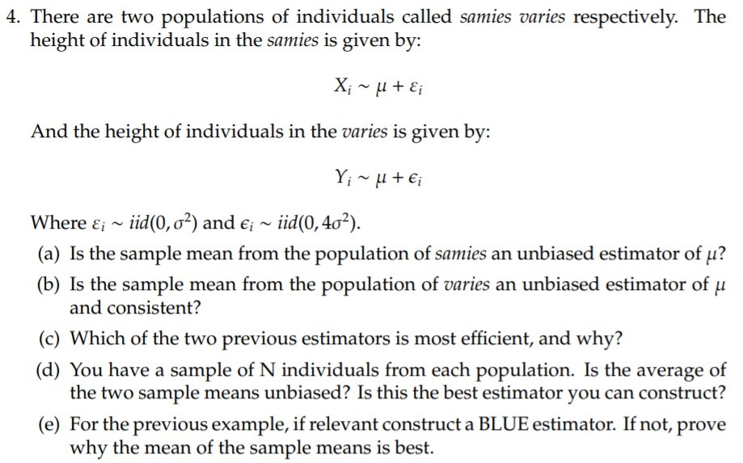

```python
Image("Screenshot_Problem_4.jpg")
```

1. a. Yes, $E[\bar{X}]=E[\frac{1}{N}\sum_{i=1}^{N}X_i]=\frac{1}{N}\sum_{i=1}^{N}E[X_i]=\frac{1}{N}\cdot N \cdot\mu_X=\mu_X$

b. Yes, $E[\bar{Y}]=E[\frac{1}{N}\sum_{i=1}^{N}Y_i]=\frac{1}{N}\sum_{i=1}^{N}E[Y_i]=\frac{1}{N}\cdot N \cdot\mu_Y=\mu_Y$. And $\lim_{N\to\infty}Var(\bar{Y})=\lim_{N\to\infty}Var(\frac{1}{N}\sum_{i=1}^{N}Y_i)=\lim_{N\to\infty}\frac{1}{N^2}\cdot N \cdot \sigma_Y^2=\lim_{N\to\infty}\frac{4\sigma^2}{N}=0$.

c. $\bar{X}$ is a more efficient estimator for its respective population mean because $Var(\bar{X})=\frac{\sigma^2}{N} \le Var(\bar{Y})$.

d. $E[\frac{\bar{X}+\bar{Y}}{2}]=E[\frac{\bar{X}}{2}] + E[\frac{\bar{Y}}{2}]=\frac{1}{2}E[\bar{X}]+\frac{1}{2}E[\bar{Y}]=\frac{\mu}{2} + \frac{\mu}{2}=\mu$\ $\therefore$ the average of the sample means is an unbiased estimator of the population mean.\ $$\min Var(a\bar{X}+b\bar{Y}) \: s.t. a + b = 1$$ Since $X_i$ and $Y_i$ are i.i.d. $$Var(a\bar{X}+b\bar{Y})=a^2Var(\bar{X})+b^2Var(\bar{Y})=a^2\sigma^2+4b^2\sigma^2$$ So, the minimization problem becomes $\min a^2\sigma^2+4b^2\sigma^2 \: s.t. a+b=1$ $$\mathscr{L}=a^2\sigma^2+4b^2\sigma^2-\lambda(a+b-1)$$ $$\frac{\partial\mathscr{L}}{\partial a}=2\sigma^2a-\lambda=0$$ $$\to a=\frac{\lambda}{2\sigma^2}$$ $$\frac{\partial\mathscr{L}}{\partial b}=8\sigma^2b-\lambda=0$$ $$\to b=\frac{\lambda}{8\sigma^2}=\frac{a}{4}$$ $$\frac{\partial{\mathscr{L}}}{\partial\lambda}=a+b-1=0$$ $$\to a + \frac{a}{4}=1$$ $$\to a = \frac{4}{5}, \: b=\frac{1}{5}$$ $\therefore$ No, the average of the sample means is not the best estimator one can construct.

e. Looking at the previous part, the best linear unbiased estimator (BLUE) of the population mean is $\hat{\mu}=\frac{4}{5}\bar{X}+\frac{1}{5}\bar{Y}$